# Multivariate models

M. Rolland

2020-09-03

# 1 To do

- decide what to do with season/ndvi
- tune model parameters
- time to event model
- redo by hand the descriptive plot (compute prevalence for each 1C nd not just smooth)
- is it OK i explore extreme temp events?

# 2 List of model covariates:

- Maternal education
- Maternal age at conception
- Active tobacco
- Maternal pre-pregnancy BMI
- Parity
- Humidity
- Season of conception
- NDVI
- Urban/rural
- cohort

# 3 Gestation duration

## 3.1 Overall

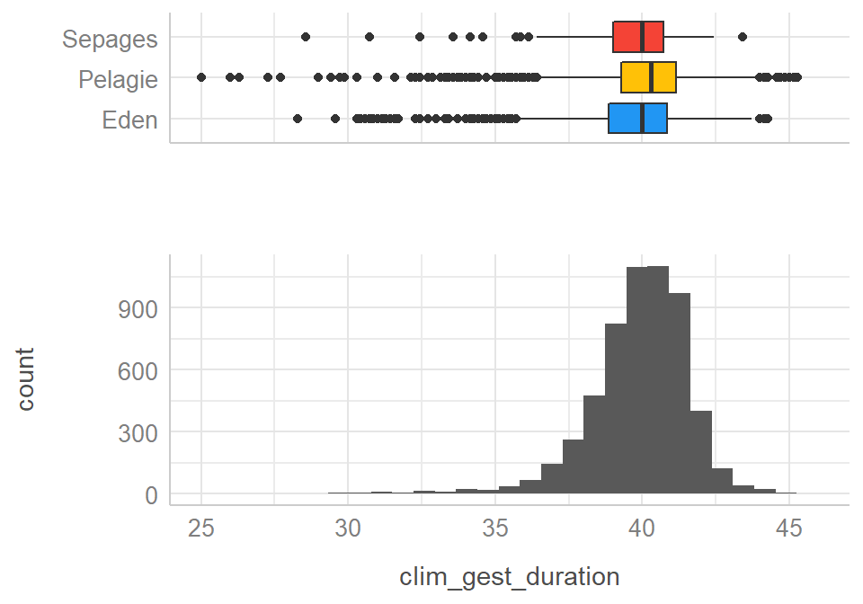

## 3.2 Above 42 GW

Number of births >= 42 GW

| clim_cohort | 42 | 43 | 44 | 45 |
| --- | --- | --- | --- | --- |
| Eden | 52 | 18 | 7 | 0 |
| Pelagie | 139 | 96 | 24 | 7 |
| Sepages | 4 | 1 | 0 | 0 |

**All seems OK with LMP dates, DOB, etc**

# 4 Preterms

Number of preterms per center

| clim_center | preterm |
| --- | --- |
| Brittany | 123 (3.7%) |
| Grenoble | 21 (4.4%) |
| Nancy | 55 (5.7%) |
| Poitiers | 53 (5.8%) |

# 5 Logistic model with no exposure

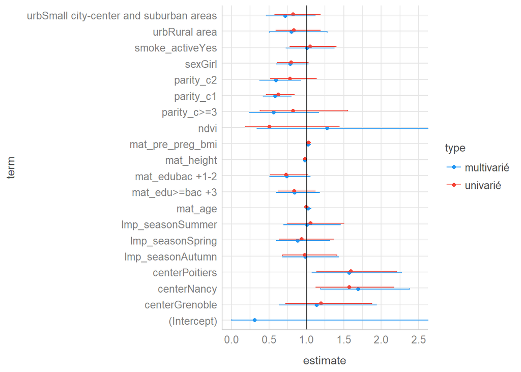

All seems consistant except for **NDVI change when included with season**. Season does not change when NDVI included.

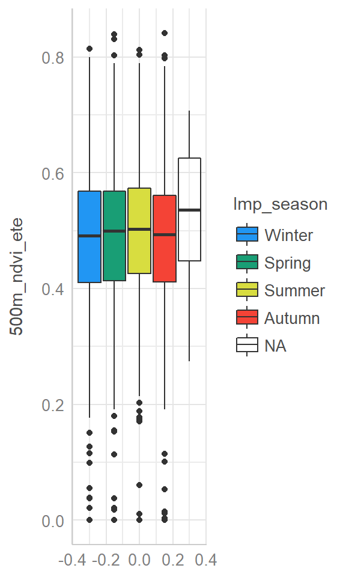

# 6 PTB vs exposure

## 6.1 Descriptive

Preterm birth prevalence vs mean pregnancy temperature:

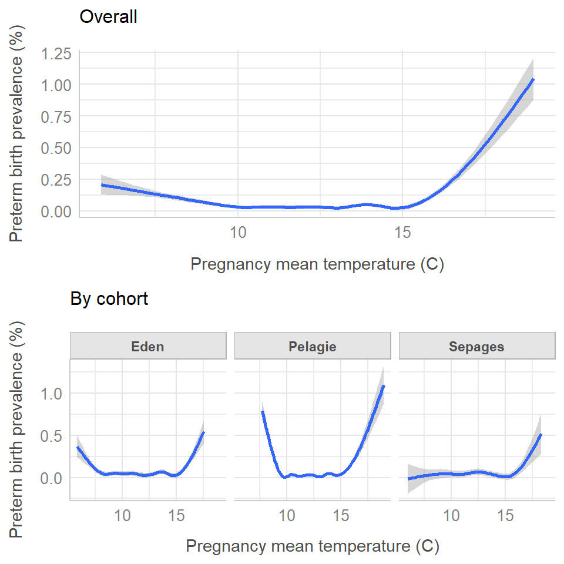

## 6.2 Notes on methods

DLNM vignette for our situation `vignette("dlnmExtended")`

Method notes Otana:

> - Relationships between term birthweight and meteorological exposures were initially modelled with minimal adjustment, and then modelled in a fully-adjusted framework.
> - The minimally-adjusted models were built for each exposure separately (mean temperature, standard deviation of temperature, mean humidity, and standard deviation of humidity), adjusting only for gestational age at birth.
> - Fully-adjusted models contained mean temperature, mean humidity, standard deviation of temperature, and standard deviation of humidity as simultaneous exposures, with adjustment for the aforementioned possible confounders.
> - We used distributed lag models with an exposure matrix of the first 37 gestational weeks for each meteorological exposure.
> - The exposure-response relationship was modelled linearly, and the lag-response relationship (reflecting the impact of exposure timing) was modelled with natural cubic splines.
> - Degrees of freedom were tested from 2 to 6, and chosen by minimizing the Akaike information criterion (AIC) in minimally-adjusted models for each exposure.
> - Then the selected values for degrees of freedom were used in building the fully-adjusted models, which contained all four exposures simultaneously.
> - We also checked for non-linearity of the exposure-response relationship with natural cubic splines, again testing degrees of freedom from 2 to 6 and choosing the degrees of freedom that minimized the AIC in minimal models.

## 6.3 Multivariate model outputs - Forward

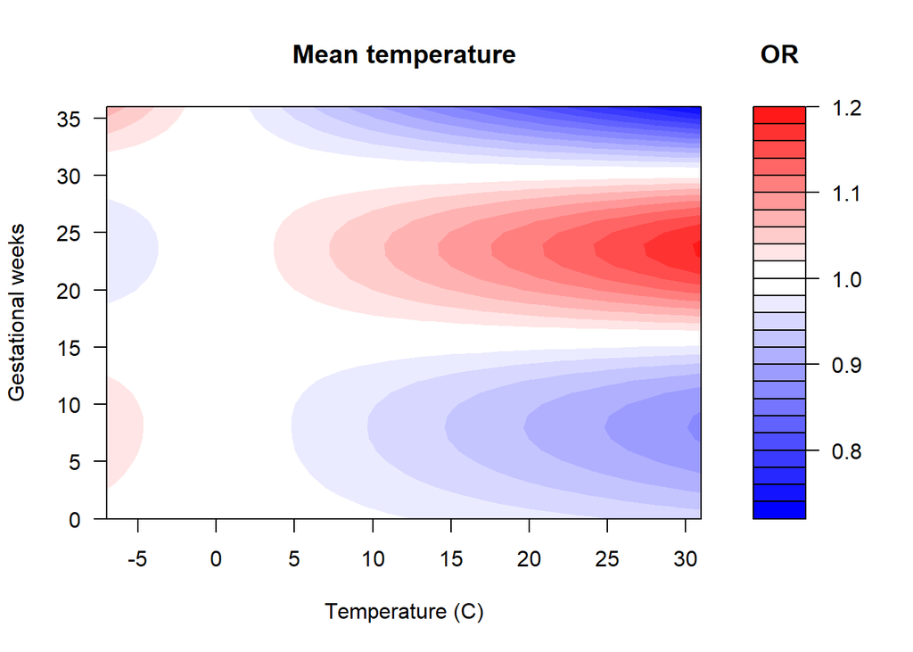

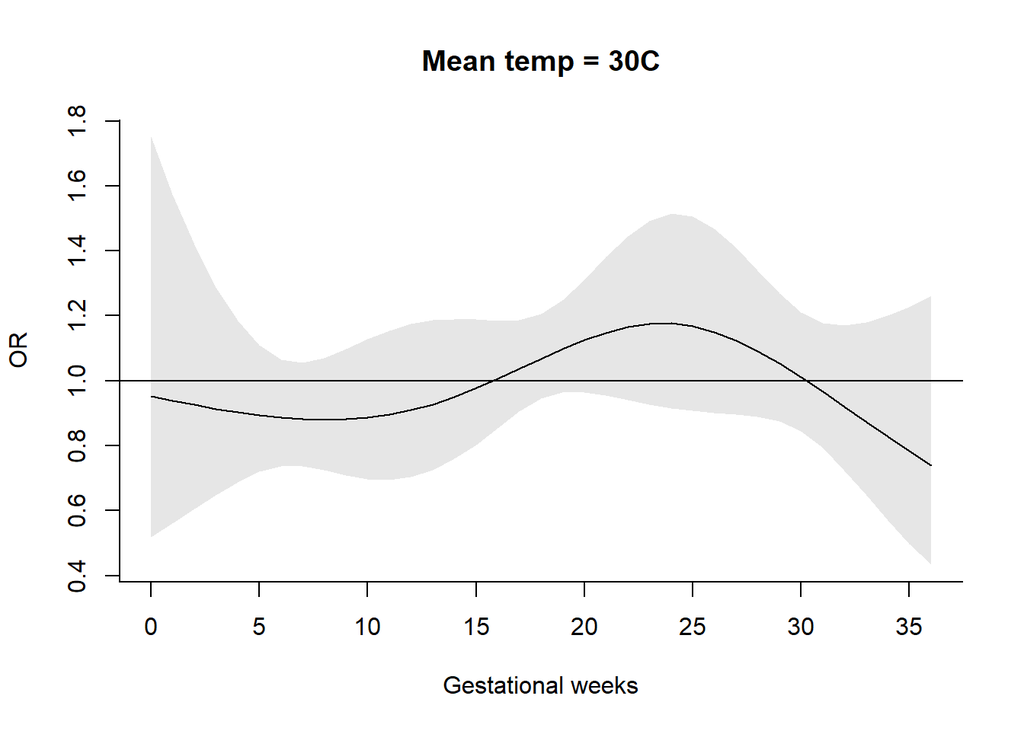

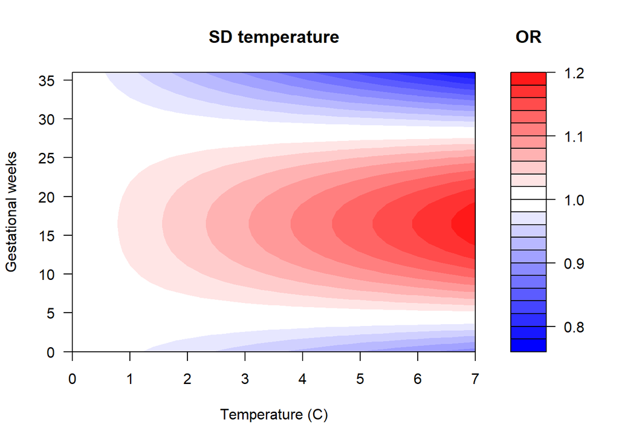

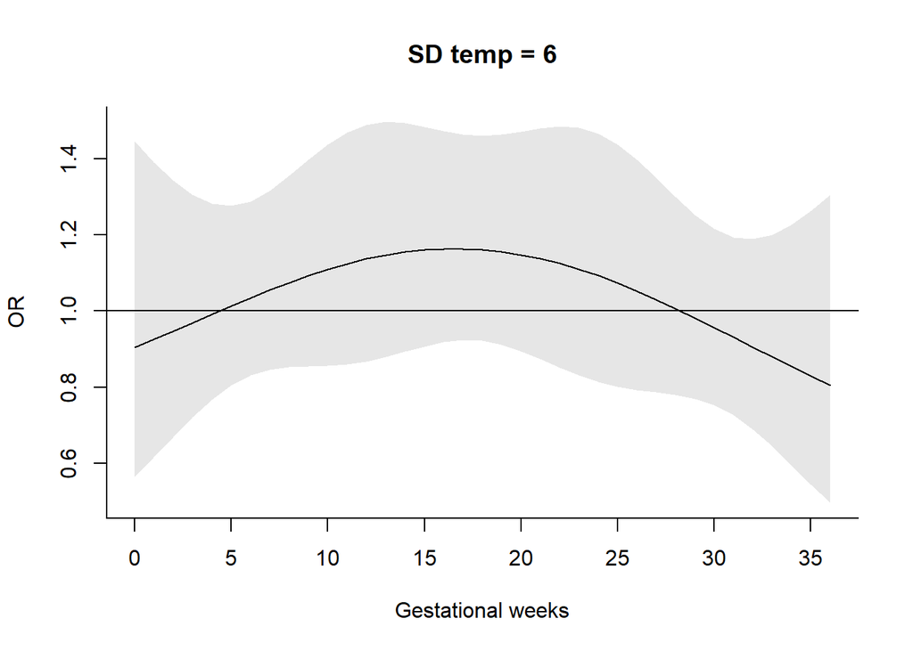

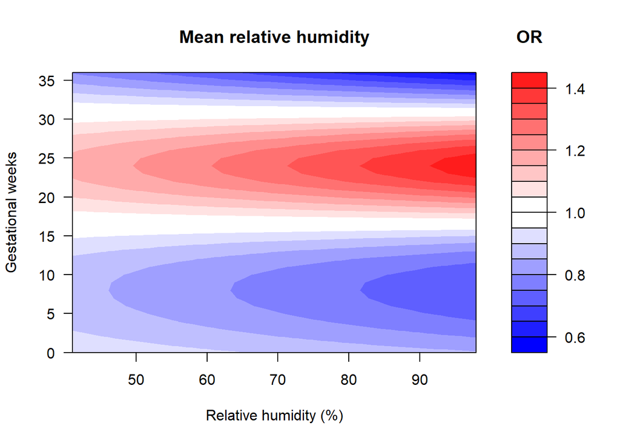

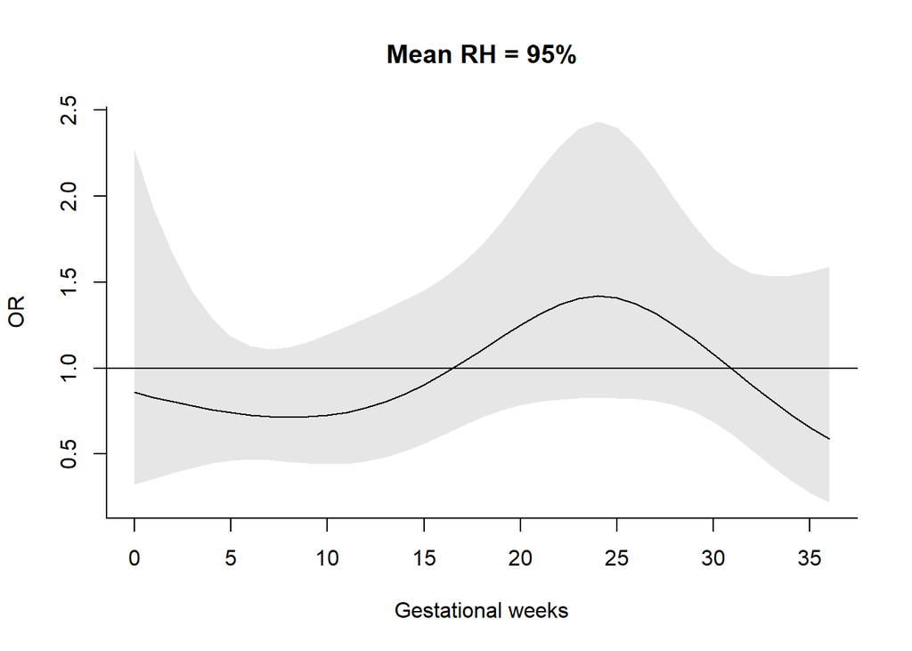

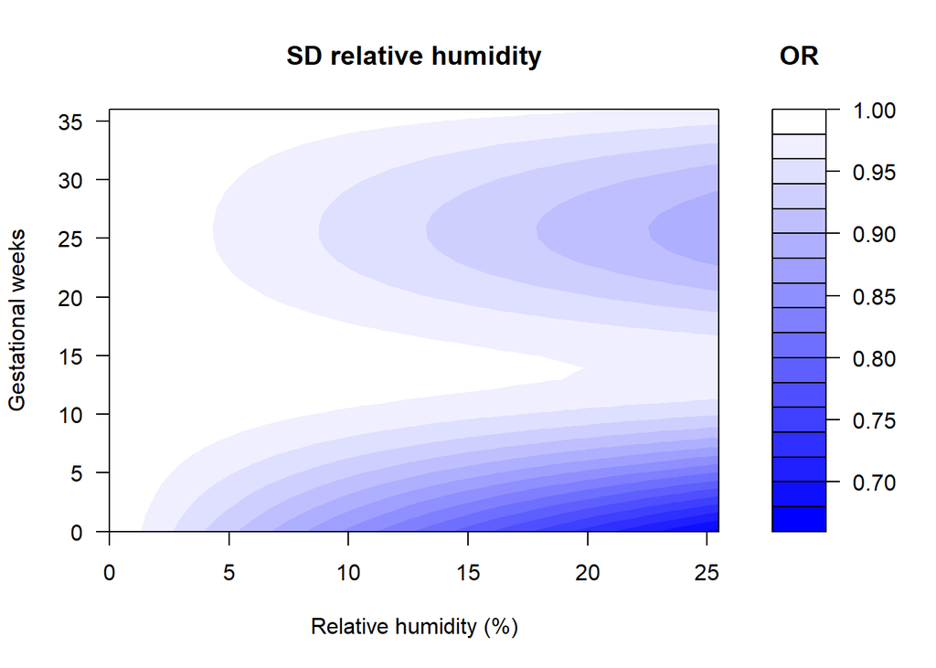

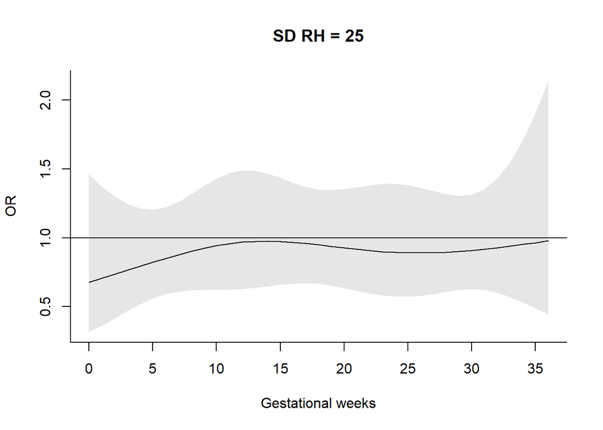

## 6.4 Multivariate model outputs - Backward

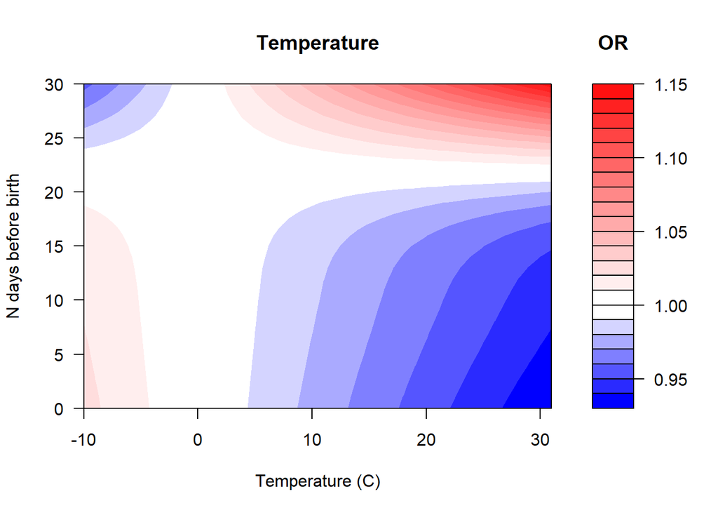

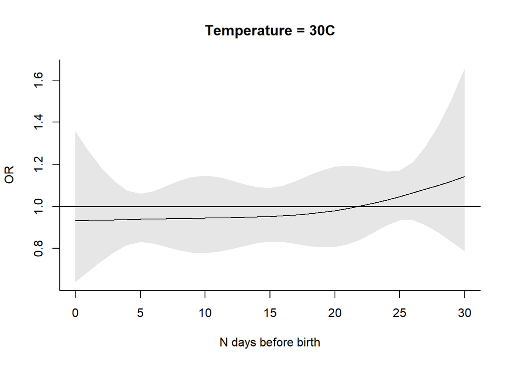

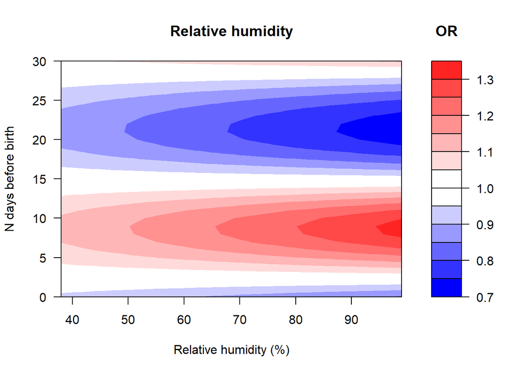

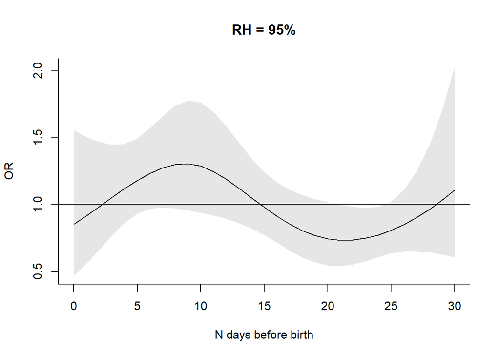